# Tutorial for HN module

```python
# import the necessary packages along with HNpy
import numpy as np
import pandas as pd
import matplotlib.pyplot as plt
import os
import HavNegpy as dd
%matplotlib qt
```

```python
# extract the data

filename = 'hn_example_data.txt'
col_names = ['log f', 'log eps2']
df = pd.read_csv(filename, sep=',',index_col=False,usecols = [0,1],names=col_names,header=None,skiprows=2,encoding='unicode_escape',engine='python')
```

[figure not shown]

```python
# plot the data

x,y = df['log f'], df['log eps2']
plt.scatter(x,y,label='example data')
plt.xlabel('log f [Hz]')
plt.ylabel('log $\epsilon$"')
plt.legend()
plt.title('Example for HN fitting')
```

```python
# instantiate the HN module
hn = dd.HN()
```

Select the ROI to fit the data using the select range method. The select range functions pops in a separate window and allows you two clicks to select the region of interest (ROI). The data in ROI is shown as image in the following cells

```python
#select range
hn = dd.HN()
x1,y1 = hn.select_range(x,y)
```

```
x_lower_limit 2.5234707551868087 x_upper_limit 4.4693345833813005
```

Plot of the ROI to fit the HN function

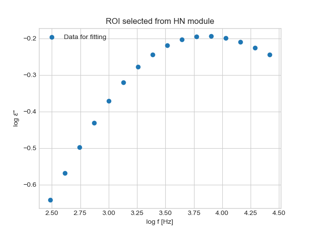

```python
#dump the initial guess parameters using dump parameters method (varies for each fn), which dumps the parameters in a json file'
#this is required before performing the first fitting as it takes the initial guess from the json file created

hn.dump_parameters_hn()
```

```
enter the beta value:0.5
enter the gamma value:1
enter the fm:3.75
enter the deps:0.5
enter the cond:0
enter the s:1
dumped_parameters {'beta': 0.5, 'gamma': 1.0, 'freq': 5623.413251903491, 'deps': 0.5, 'cond': 0.0, 'n': 1.0}
```

```
()
```

```python
# view the initial fit based on the dumped parameters
# the plot is shown as a image in the next cell

hn.initial_view_hn(x1,y1)
```

```
loaded parameters
 {'beta': 0.5, 'gamma': 1.0, 'freq': 5623.413251903491, 'deps': 0.5, 'cond': 0.0, 'n': 1.0}
```

Plot of the initial fit based on the supplied parameters

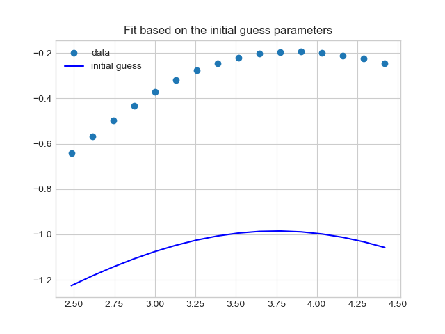

```python
# perform least squares fitting
# the plot is shown as a image in the next cell

hn.fit(x1,y1)
```

```
Choose the fit function
 1 -- HN, 2 -- HN with cond, 3 -- Hn-flank, 4 -- double HN, 5 -- double HN with cond:1
0.7326563571608663 0.34641197051059136 1945.8637251236246 3.2548369440810547
log fmax: 3.8521833734663224
fit parameters dumped for next iteration {'beta': 0.7326563571608663, 'gamma': 0.34641197051059136, 'freq': 1945.8637251236246, 'deps': 3.2548369440810547, 'cond': 0, 'n': 0}
```

Plot of the final fit of the HN function to the data

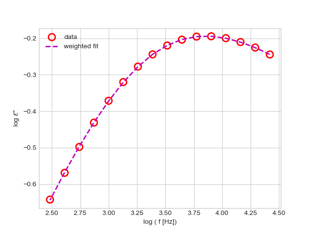

```python
#create a file to save fit results using create_analysis file method
#before saving fit results an analysis file has to be created

hn.create_analysis_file()
```

```
Do you want to use an existing file to save fit results?
 eg: existing file to save HN parameters, y or n:n
Choose the fit function
 1 -- HN, 2 -- HN with cond, 3 -- HN-flank, 4 -- double HN, 5 -- double HN with cond:1
Enter the analysis_file_name:hn_fit.TXT
file did not exist, created hn_fit.TXT
```

```
()
```

```python
#save the fit results using save_fit method of the corresponding fit function
#takes one argument, read more on the documentation

hn.save_fit_hn(1)
```

```
()
```